# GEDI: Quick intro

# Pre-processing

## Load libraries

```r
library(scuttle)
library(scran)
library(scater)
library(uwot)
library(SingleCellExperiment)
library(ggplot2)
library(HDF5Array)
library(GEDI)
set.seed(43)
```

## Downloading data

The raw count matrices and metadata are available through the SeuratData package:

```r
library(SeuratData)
InstallData("pbmcsca") # Install pbmcsca object
data("pbmcsca") # Load the Seurat Object
```

We will generate a Single Cell Experiment (SCE) Object.

```r
meta<- pbmcsca[[]] # Obtaining metadata
meta$Barcode<- rownames(meta) # Naming Barcode
sce<- SingleCellExperiment(list(counts=Seurat::GetAssayData(object = pbmcsca, slot = "counts")), colData=meta) # create SCE
sce
```

```
class: SingleCellExperiment
dim: 33694 31021
metadata(0):
assays(1): counts
rownames(33694): TSPAN6 TNMD ... RP11-107E5.4 RP11-299P2.2
rowData names(0):
colnames(31021): pbmc1_SM2_Cell_108 pbmc1_SM2_Cell_115 ...
  pbmc2_inDrops_1_TGAATCCT.TTATGCGA.CATCTCCC
  pbmc2_inDrops_1_TGAGCACA.GAGCCTTA.CGAGTCTG
colData names(11): orig.ident nCount_RNA ... Method Barcode
reducedDimNames(0):
altExpNames(0):
```

## Quality control steps

We will perform basic QC steps using the scuttle library.

```r
sce<- addPerCellQC(sce, subsets=list(Mito=grep("MT-", rownames(sce) )) )
sce$log10_total_counts<- log10(sce$sum)
sce$log10_total_features_by_counts<- log10(sce$detected)
```

Visualize the quality of the data

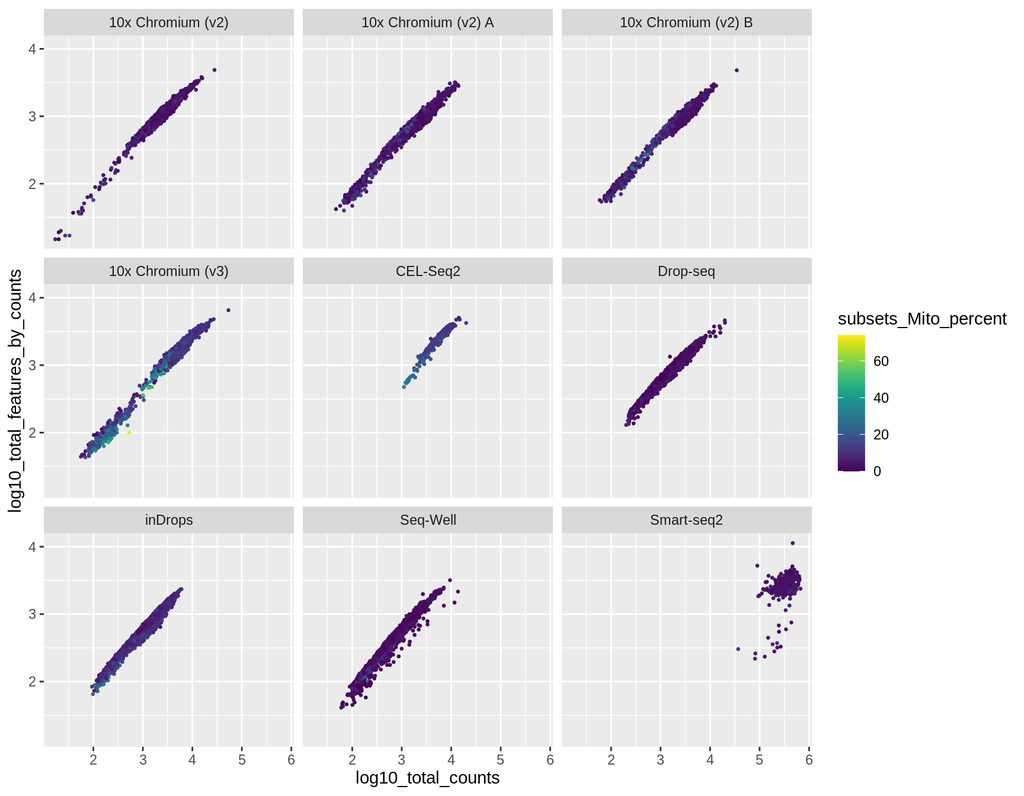

```r
ggplot(data.frame(colData(sce)), aes(log10_total_counts, log10_total_features_by_counts,color=subsets_Mito_percent ) )+
    geom_point(size=0.5) +
    viridis::scale_color_viridis() +
    facet_wrap(~sce$Method)
```

Filtering low-quality cells

```r
filter<- sce$log10_total_counts > 2.5 &
    sce$log10_total_features_by_counts > 2 &
    sce$subsets_Mito_percent <= 20
sce<- sce[,filter]
```

```r
cells_donor1_10x<- sample(colnames(sce)[sce$Method == "10x Chromium (v2) A" & sce$orig.ident == "pbmc1" ], 200)
cells_donor1_dropseq<- sample(colnames(sce)[sce$Method == "Drop-seq" & sce$orig.ident == "pbmc1" ], 200)
sce<- sce[, c(cells_donor1_10x, cells_donor1_dropseq)]
```

Filtering low-expressed genes

```r
# We kept genes that had more than 3 counts in more than 3 cells across the entire dataset
sum_genes<- rowSums(assay(sce, "counts")>3)
genes_use<- sum_genes>3
table(genes_use)
```

```
genes_use
FALSE  TRUE
33126   568
```

```r
genes_use<- names(which(genes_use))
```

```r
sce<- sce[genes_use,]
sce
```

```
class: SingleCellExperiment
dim: 568 400
metadata(0):
assays(1): counts
rownames(568): CD99 SLC25A5 ... AC090498.1 AP000769.1
rowData names(0):
colnames(400): pbmc1_10x_v2_A_ACACTGACAGCCACCA
  pbmc1_10x_v2_A_GAATAAGTCCAAACTG ... pbmc1_Drop_AATTACGCGATG
  pbmc1_Drop_TATCAGATGGTC
colData names(19): orig.ident nCount_RNA ... log10_total_counts
  log10_total_features_by_counts
reducedDimNames(0):
altExpNames(0):
```

# Run GEDI

After pre-processing, we are ready to run GEDI. First, we need to indicate a vector of samples. We will create a vector that indicates each sample, which in this case is a combination of the donor and single-cell technology used.

```r
sce$donor_sample<- paste0(sce$orig.ident, ".", sce$Method)
meta<- data.frame(colData(sce))
```

**IMPORTANT:** The vector of samples (and potentially the metadata) needs to be in the same order as the gene expression matrix.

We will run GEDI using the raw counts.

```r
# Accesing the raw counts in the SCE object and convert to a sparse Matrix format
raw_counts<- as(as.matrix(assay(sce, "counts")), "dgCMatrix")
```

Now, we are ready to run GEDI. These are the main arguments:

- Samples: Batch variable to use. It should be a character vector indicating which sample belongs to each cell.
- Expression matrix: Could be one of the following:
  - Y: The log-transformed (and possibly normalized) gene expression matrix.
  - M: The raw read count matrix. It can also be a list of two matrices, in which case they are considered as paired observations whose log-ratio must be modelled.
- K: The number of latent variables.
- mode: Two values are allowed:
  - Bsphere: L2 norms of B columns are fixed. Interpretation is that we’re projecting the data on a hyperellipsoid of dimension K.
  - Bl2: L2 norm of the entire B matrix is fixed. Interpretation is that we’re projecting the data on a lower-dimensional hyperplane with dimension K.
- itelim: Number of iterations for optimization.

**Optional arguments**:

- C: The gene-level biological prior. If NULL, it means that there is no prior information for Z.
- H: Sample-level prior for sources of variation. If NULL, there will be no prior for Qi.
- oi_shrinkage: Shrinkage multiplier for oi (offset vector per sample i).

For this example, we are going to use GEDI with the raw counts and the Bsphere mode.

```r
## Set up GEDI model
model <- new("GEDI") # Initialize GEDI object
model$setup(Samples = sce$donor_sample, # Vector indicating which sample belongs to each cell
            colData=data.frame(colData(sce)), # Metadata (optional)
            M = raw_counts, # Expression data
            K = 5, # Number of latent variables to use
            mode = "Bsphere", # Modes to use: Either Bsphere (hyperellipsoid) or Bl2 (hyperplane)
            oi_shrinkage = 0.001 # Shrinkage multiplier for oi. In here we use 0.001, to better accommodated the mean abundance differences that exist between multiple scRNA-seq technologies.
            )
```

```
Setting up the GEDI model...
```

```r
model$initialize.LVs(randomSeed = 1) # initialize LVs
```

```
Initializing LVs...
```

```
  Initializing oi...
```

```
  Performing initial decompsition of Y...
```

```r
model$optimize(iterations=40) # run model with 500 iterations
```

```
Performing block coordinate descent optimization...
```

```
  Iteration 1/40 (total 1)...
```

```
1.135132
1
Mean(o): -0.7547346 ; Var(o): 1.065657 ; Var(si): 0.008446325
```

```
  Iteration 2/40 (total 2)...
```

```
0.8738663
1
Mean(o): -0.7545425 ; Var(o): 1.376523 ; Var(si): 0.03537189
```

```
  Iteration 3/40 (total 3)...
```

```
0.749041
1
Mean(o): -0.7544743 ; Var(o): 1.598822 ; Var(si): 0.06243741
```

```
  Iteration 4/40 (total 4)...
```

```
0.6616295
1
Mean(o): -0.7544268 ; Var(o): 1.803197 ; Var(si): 0.07344039
```

```
  Iteration 5/40 (total 5)...
```

```
0.590758
1
Mean(o): -0.7543819 ; Var(o): 2.012816 ; Var(si): 0.07317494
```

```
  Iteration 6/40 (total 6)...
```

```
0.5317217
1
Mean(o): -0.7543347 ; Var(o): 2.229724 ; Var(si): 0.06837794
```

```
  Iteration 7/40 (total 7)...
```

```
0.4827452
1
Mean(o): -0.7542839 ; Var(o): 2.449492 ; Var(si): 0.06283484
```

```
  Iteration 8/40 (total 8)...
```

```
0.4424246
1
Mean(o): -0.7542296 ; Var(o): 2.666398 ; Var(si): 0.05785041
```

```
  Iteration 9/40 (total 9)...
```

```
0.4093384
1
Mean(o): -0.7541732 ; Var(o): 2.875695 ; Var(si): 0.05358362
```

```
  Iteration 10/40 (total 10)...
```

```
0.3821151
1
Mean(o): -0.7541157 ; Var(o): 3.074439 ; Var(si): 0.04988358
```

```
  Iteration 11/40 (total 11)...
```

```
0.3595567
1
Mean(o): -0.7540585 ; Var(o): 3.261278 ; Var(si): 0.04659177
```

```
  Iteration 12/40 (total 12)...
```

```
0.3406975
1
Mean(o): -0.7540026 ; Var(o): 3.435828 ; Var(si): 0.04358846
```

```
  Iteration 13/40 (total 13)...
```

```
0.3247835
1
Mean(o): -0.7539488 ; Var(o): 3.598269 ; Var(si): 0.04077346
```

```
  Iteration 14/40 (total 14)...
```

```
0.3112258
1
Mean(o): -0.753898 ; Var(o): 3.749168 ; Var(si): 0.03808883
```

```
  Iteration 15/40 (total 15)...
```

```
0.2995702
1
Mean(o): -0.753851 ; Var(o): 3.889245 ; Var(si): 0.03552969
```

```
  Iteration 16/40 (total 16)...
```

```
0.2894696
1
Mean(o): -0.7538084 ; Var(o): 4.019208 ; Var(si): 0.0331123
```

```
  Iteration 17/40 (total 17)...
```

```
0.280656
1
Mean(o): -0.753771 ; Var(o): 4.139725 ; Var(si): 0.03084993
```

```
  Iteration 18/40 (total 18)...
```

```
0.2729185
1
Mean(o): -0.7537398 ; Var(o): 4.25143 ; Var(si): 0.02874577
```

```
  Iteration 19/40 (total 19)...
```

```
0.2660887
1
Mean(o): -0.7537155 ; Var(o): 4.35493 ; Var(si): 0.02679375
```

```
  Iteration 20/40 (total 20)...
```

```
0.2600304
1
Mean(o): -0.7536991 ; Var(o): 4.450803 ; Var(si): 0.02498213
```

```
  Iteration 21/40 (total 21)...
```

```
0.2546327
1
Mean(o): -0.7536913 ; Var(o): 4.539592 ; Var(si): 0.02329677
```

```
  Iteration 22/40 (total 22)...
```

```
0.249805
1
Mean(o): -0.7536929 ; Var(o): 4.621797 ; Var(si): 0.02172341
```

```
  Iteration 23/40 (total 23)...
```

```
0.2454723
1
Mean(o): -0.7537046 ; Var(o): 4.697875 ; Var(si): 0.02024894
```

```
  Iteration 24/40 (total 24)...
```

```
0.241572
1
Mean(o): -0.7537272 ; Var(o): 4.768251 ; Var(si): 0.01886197
```

```
  Iteration 25/40 (total 25)...
```

```
0.2380516
1
Mean(o): -0.7537612 ; Var(o): 4.83332 ; Var(si): 0.01755271
```

```
  Iteration 26/40 (total 26)...
```

```
0.2348662
1
Mean(o): -0.7538072 ; Var(o): 4.89345 ; Var(si): 0.0163126
```

```
  Iteration 27/40 (total 27)...
```

```
0.2319776
1
Mean(o): -0.7538657 ; Var(o): 4.948985 ; Var(si): 0.015134
```

```
  Iteration 28/40 (total 28)...
```

```
0.2293529
1
Mean(o): -0.7539371 ; Var(o): 5.000245 ; Var(si): 0.01400989
```

```
  Iteration 29/40 (total 29)...
```

```
0.2269639
1
Mean(o): -0.7540217 ; Var(o): 5.047525 ; Var(si): 0.01293376
```

```
  Iteration 30/40 (total 30)...
```

```
0.2247859
1
Mean(o): -0.7541198 ; Var(o): 5.091099 ; Var(si): 0.01189943
```

```
  Iteration 31/40 (total 31)...
```

```
0.2227976
1
Mean(o): -0.7542316 ; Var(o): 5.131221 ; Var(si): 0.01090105
```

```
  Iteration 32/40 (total 32)...
```

```
0.2209802
1
Mean(o): -0.7543572 ; Var(o): 5.168128 ; Var(si): 0.009932974
```

```
  Iteration 33/40 (total 33)...
```

```
0.2193175
1
Mean(o): -0.7544966 ; Var(o): 5.202036 ; Var(si): 0.008989768
```

```
  Iteration 34/40 (total 34)...
```

```
0.217795
1
Mean(o): -0.7546499 ; Var(o): 5.233147 ; Var(si): 0.008066133
```

```
  Iteration 35/40 (total 35)...
```

```
0.2164
1
Mean(o): -0.7548172 ; Var(o): 5.261647 ; Var(si): 0.00715693
```

```
  Iteration 36/40 (total 36)...
```

```
0.2151214
1
Mean(o): -0.7549984 ; Var(o): 5.287704 ; Var(si): 0.006257253
```

```
  Iteration 37/40 (total 37)...
```

```
0.2139493
1
Mean(o): -0.7551935 ; Var(o): 5.311471 ; Var(si): 0.005362668
```

```
  Iteration 38/40 (total 38)...
```

```
0.2128753
1
Mean(o): -0.7554028 ; Var(o): 5.333084 ; Var(si): 0.004469814
```

```
  Iteration 39/40 (total 39)...
```

```
0.2118924
1
Mean(o): -0.7556264 ; Var(o): 5.352657 ; Var(si): 0.003577789
```

```
  Iteration 40/40 (total 40)...
```

```
0.2109948
1
Mean(o): -0.7558646 ; Var(o): 5.370278 ; Var(si): 0.002691327
```

We check convergence of the GEDI model.

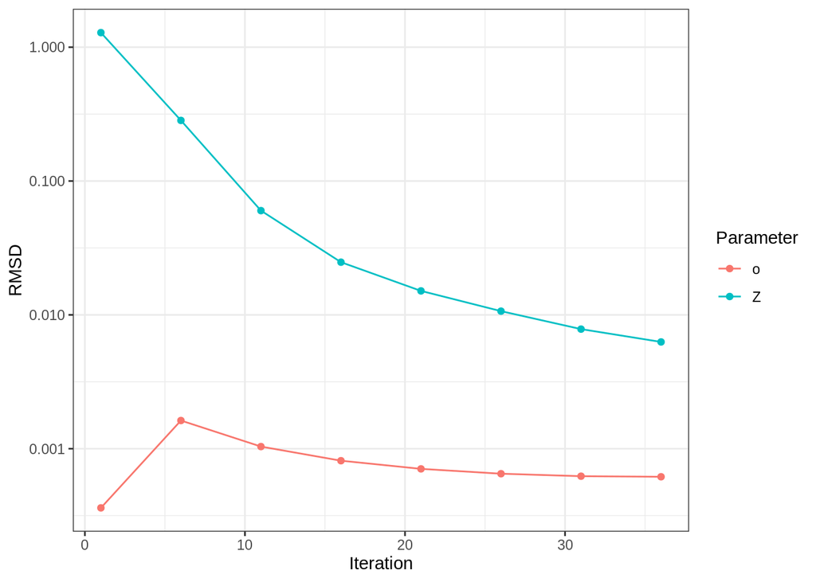

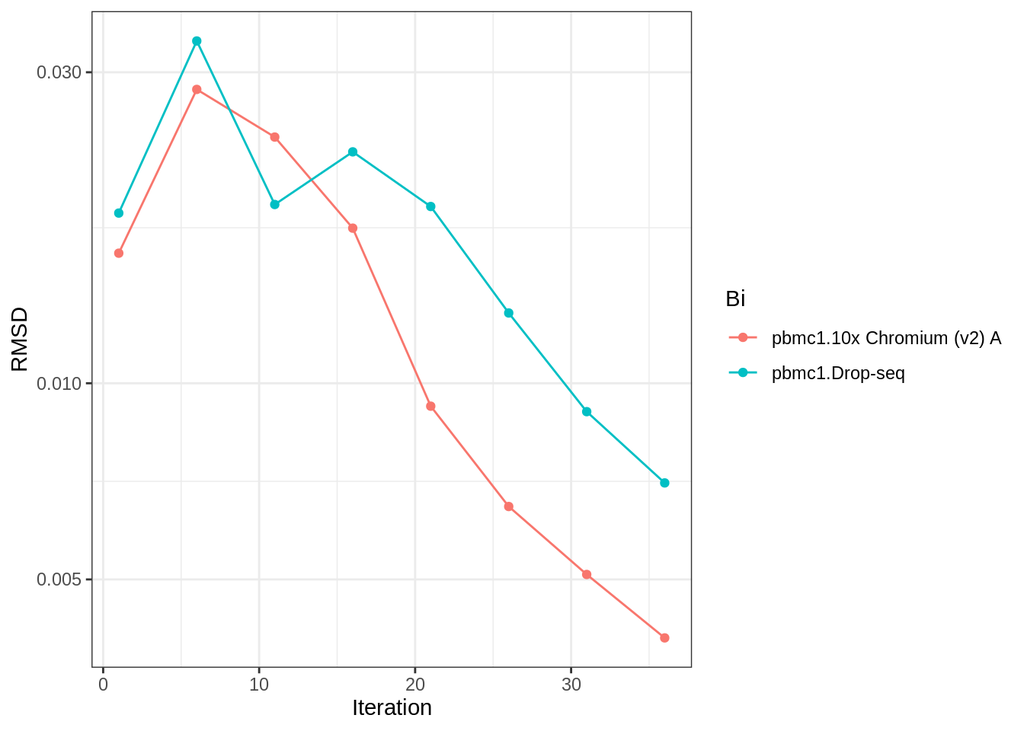

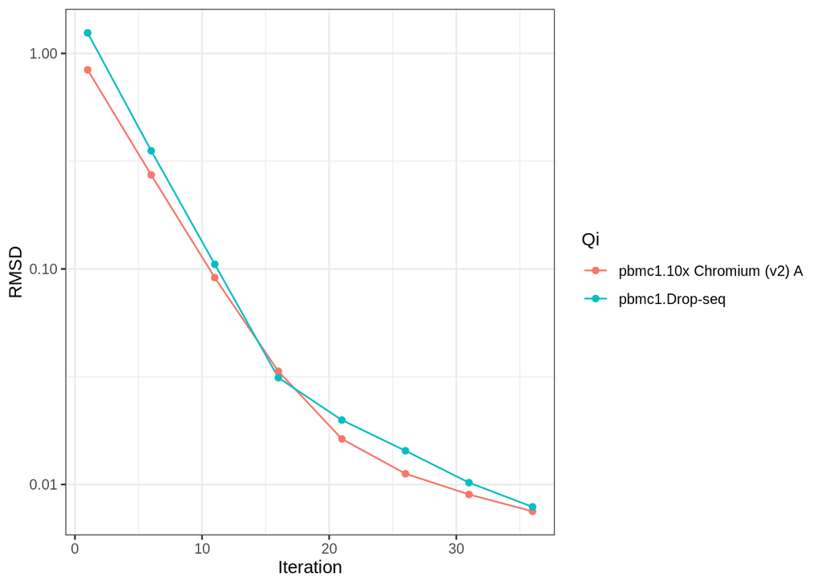

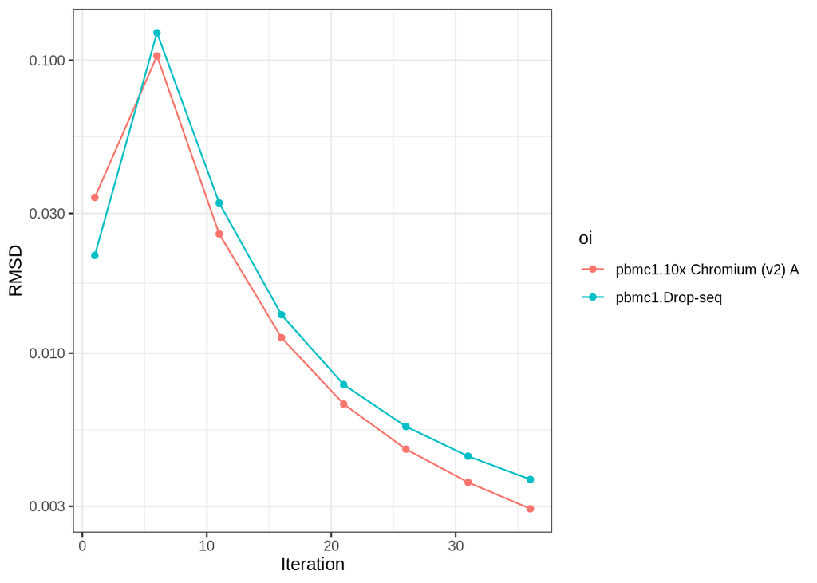

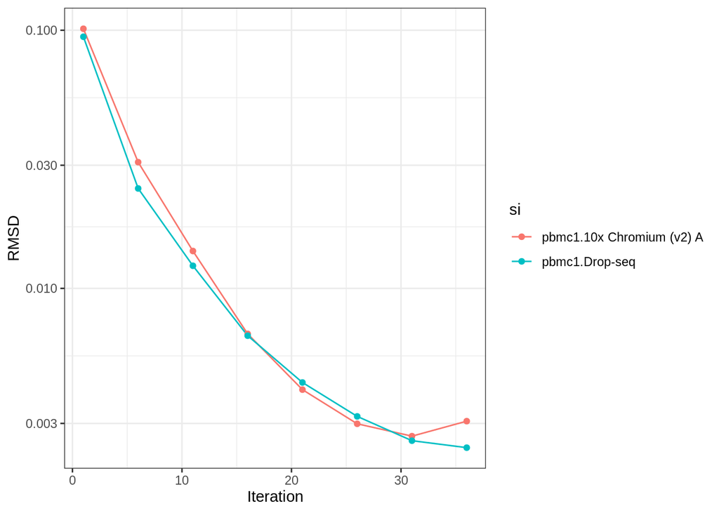

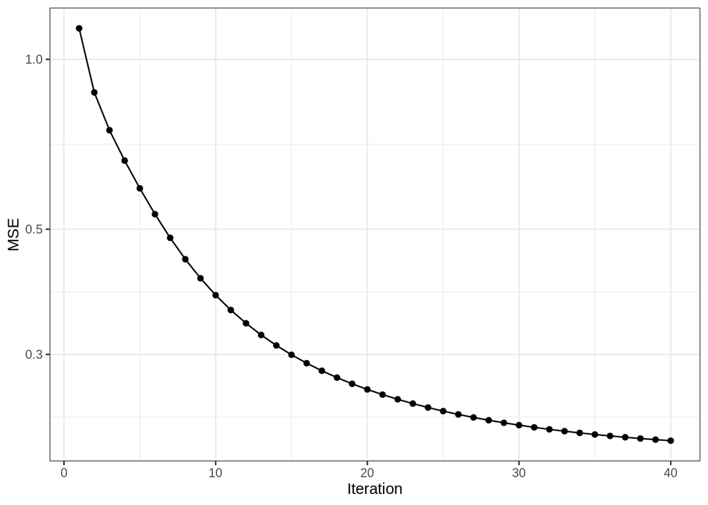

```r
model$plotTracking()
```

These plots show the convergence of the different components of the model (o, Z, Bi, Qi, oi and si). The last plot shows the convergence of the mean squared error of the model.

**IMPORTANT:** GEDI reorders the cells by sample, so we need to reorder the original metadata.

```r
# Reorder meta
meta<- meta[model$aux$cellIDs,]
```

# Visualize integration results

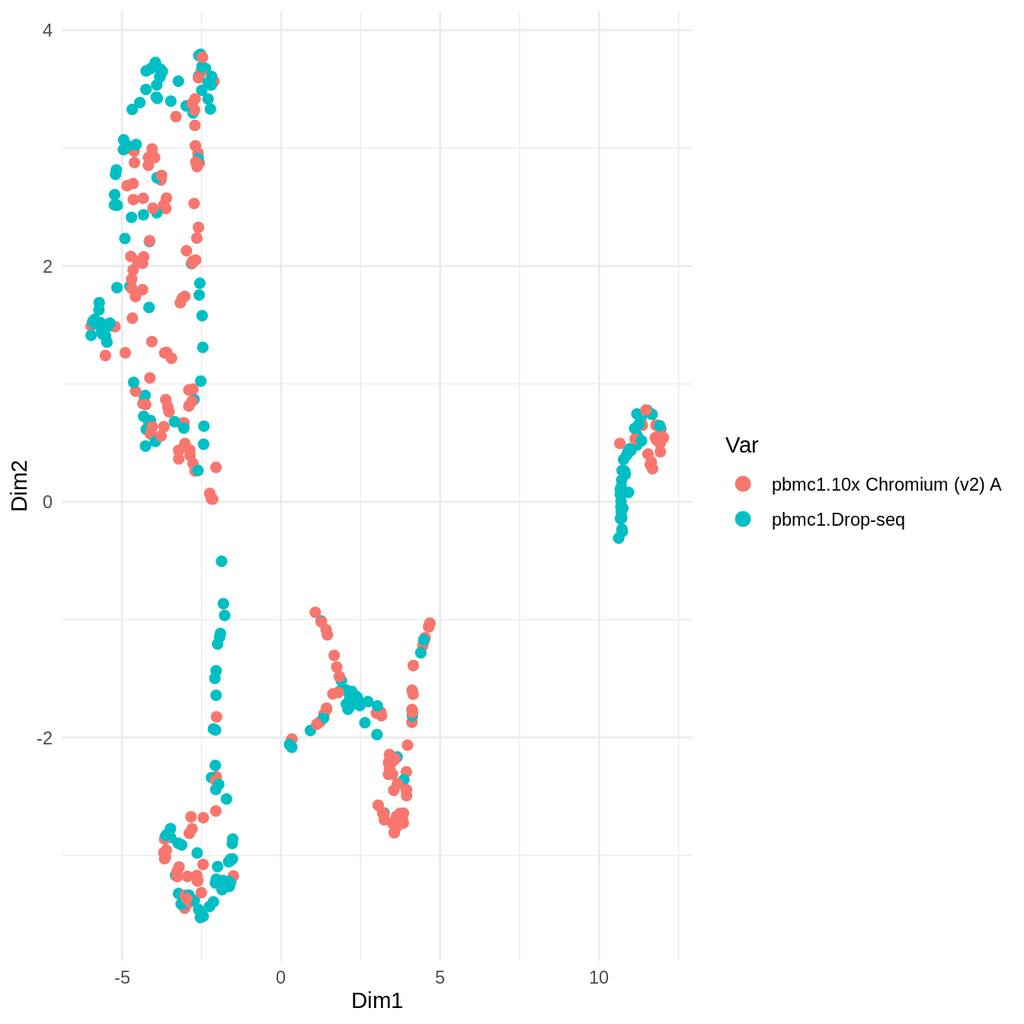

```r
# Generating svd
svd_res <- svd.gedi( model )
embedding_res_svd<- svd_res$v %*% diag(svd_res$d)
colnames(embedding_res_svd)<- paste0("embedding", 1:ncol(embedding_res_svd))

# Generating umap of 2 dimensions
umap_2_res <- umap(embedding_res_svd, min_dist=0.01, metric="euclidean")
colnames(umap_2_res)<- paste0("umap", 1:2)
rownames(umap_2_res)<- model$aux$cellIDs
umap_2_res<- data.frame(umap_2_res)

## Plot embeddings
plot_embedding( umap_2_res, meta$donor_sample, size_point=2)
```

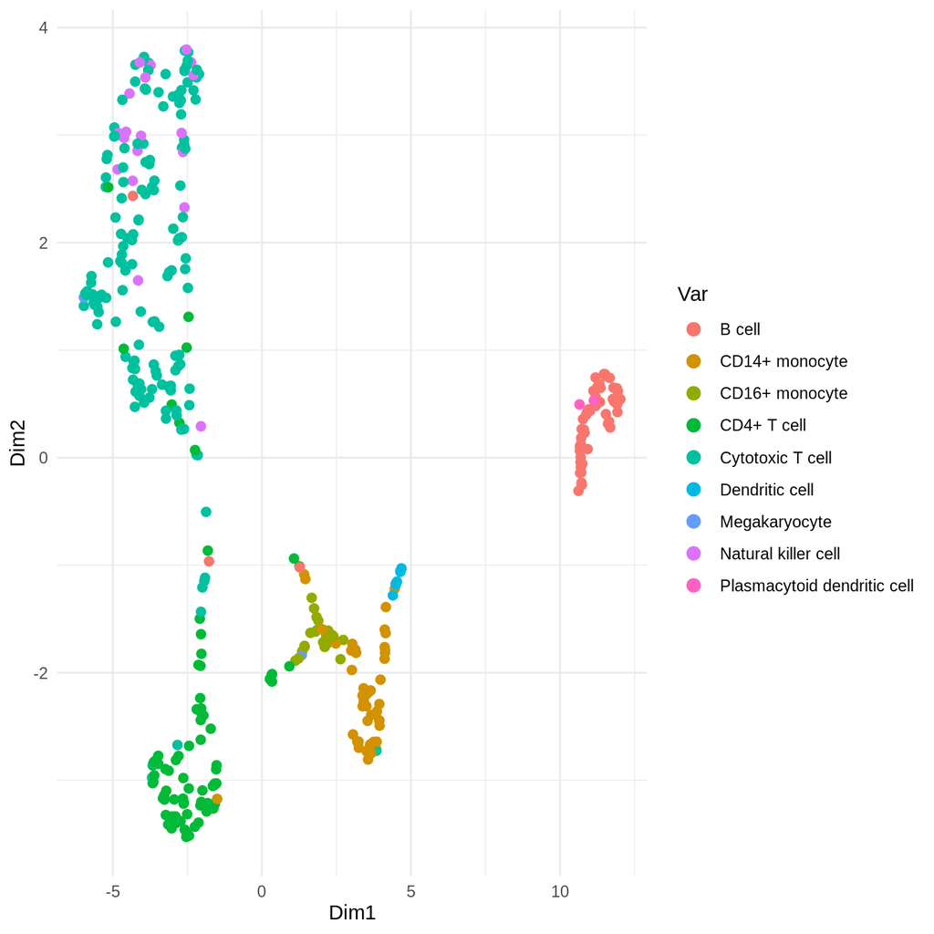

```r
plot_embedding( umap_2_res, meta$CellType, size_point=2)
```

We observe clear separation between the cell types without any obvious separation by the single-cell technology.